# Comparison of Extraction Methods (peptides)

# 6 Plasma

contrasts:

- Plasma_AFA - Plasma_TwoPhase_AFA

Upset plot for all condition types.

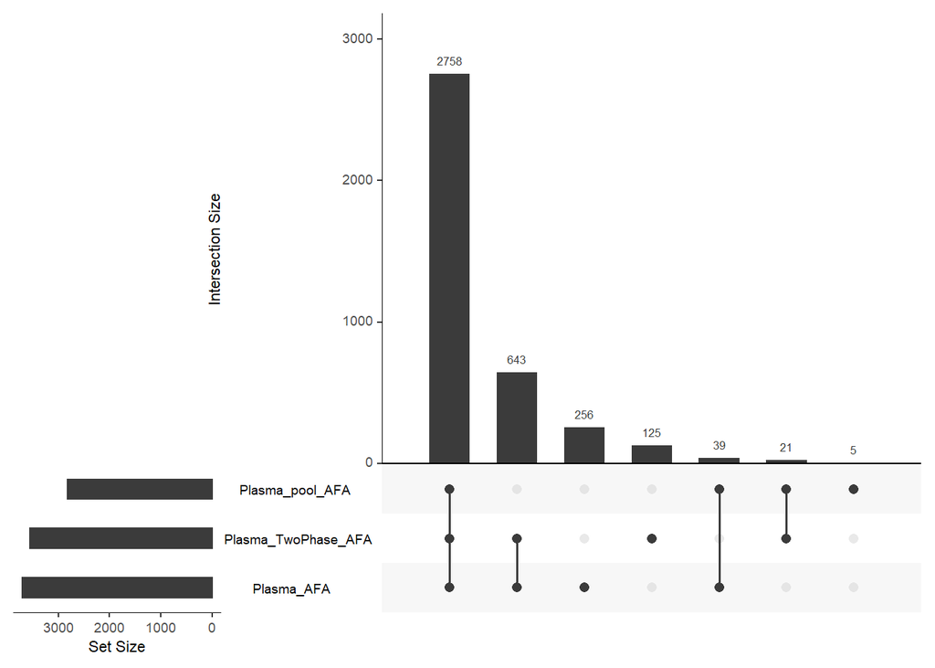

## 6.1 Plasma: Overlap, uniqueness of features

The plot shows the interaction of sets between different variables depending on their presence. The dots in the UpSet plot specify if the criteria for presence are fulfilled: Presence is defined by a feature being measured in at least one sample of a set.

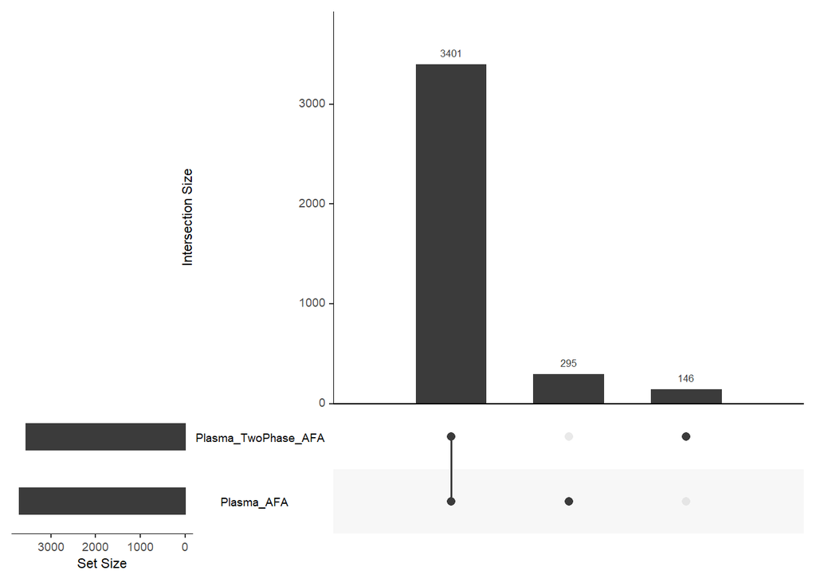

Only continue with the shared features in the following analyses.

## 6.2 Plasma: CV

```
## [1] "mean: Plasma_AFA"
```

```
## [1] 4.612797
```

```
## [1] "mean: Plasma_TwoPhase_AFA"
```

```
## [1] 3.659196
```

```
##
##  Wilcoxon signed rank test with continuity correction
##
## data:  cv_a and cv_b
## V = 2858252, p-value < 2.2e-16
## alternative hypothesis: true location shift is not equal to 0
```

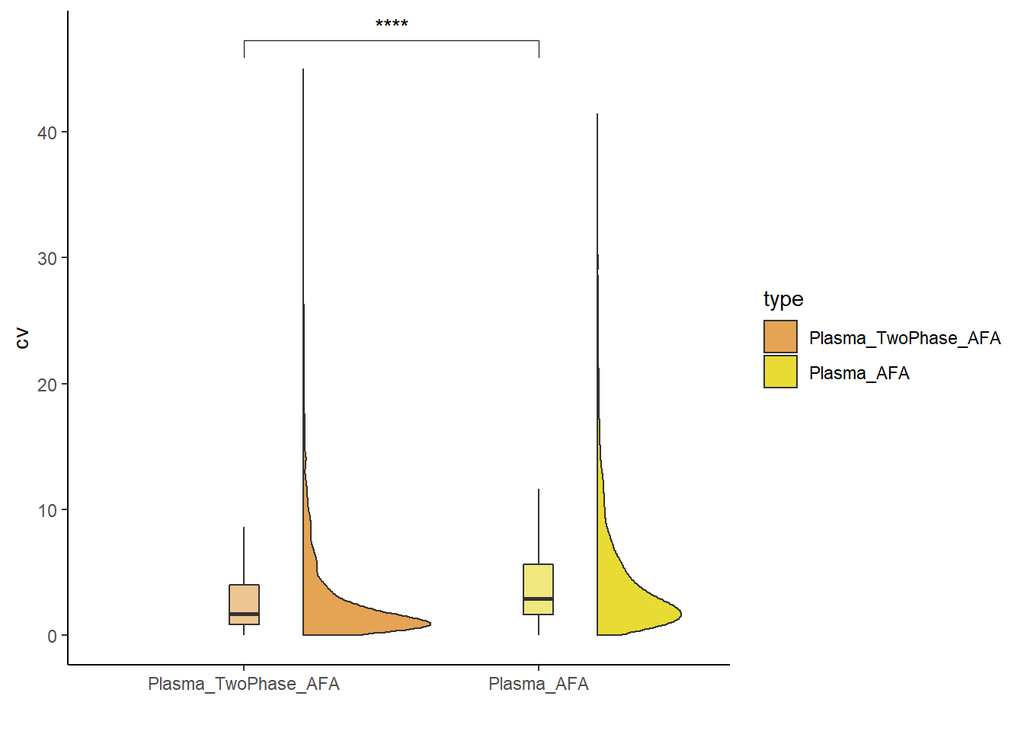

## 6.3 Plasma: Differential expression analysis

```
## [1] "## contrast: plasma_AFA - plasma_TwoPhase_AFA"
```

|  | logFC | AveExpr | t | P.Value | adj.P.Val | B |
| --- | --- | --- | --- | --- | --- | --- |
| AAAATGTIFTFR | -0.659573203 | 12.721079 | -1.24492235 | 2.548290e-01 | 0.481485193 | -6.018158199 |
| AAAFEEQENETVVVK | 0.032908440 | 9.251499 | 0.12789222 | 9.026128e-01 | 0.955724185 | -6.733214608 |
| AAATGPSFWLGNETLK | 1.415069907 | 8.420760 | 6.18342471 | 5.321132e-04 | 0.019459321 | 0.272779324 |
| AACAQLNDFLQEYGTQGCQV | -0.393383159 | 6.743821 | -0.98450268 | 4.428588e-01 | 0.638300627 | -5.629064393 |
| AADAEAEVASLNR | -1.369887795 | 8.334618 | -4.28952748 | 1.491696e-02 | 0.136331933 | -2.491116301 |
| AADDTWEPFASGK | 0.979471269 | 13.186912 | 3.25069328 | 1.487396e-02 | 0.136331933 | -3.233505310 |
| AADIEQQAVFAVFDENK | -3.378798193 | 7.728606 | -8.45596919 | 2.120538e-02 | 0.163404672 | -2.435469768 |
| AAFTECCQAADK | 0.242046028 | 12.244802 | 1.21313253 | 2.660036e-01 | 0.492021693 | -6.054268945 |
| AAISGENAGLVR | -0.105496751 | 13.714193 | -0.88642122 | 4.060013e-01 | 0.608126236 | -6.387132391 |
| AALTELSLGSAYQAMILGVDSK | -0.474912151 | 11.753502 | -3.07037863 | 2.332856e-02 | 0.171361600 | -3.545453141 |

[output cut: 490 more lines]

## 6.4 Plasma: Association to physico-chemical parameters

Take the t-values and plot against the GRAVY-Score and Isoelectric point (for shared features)..

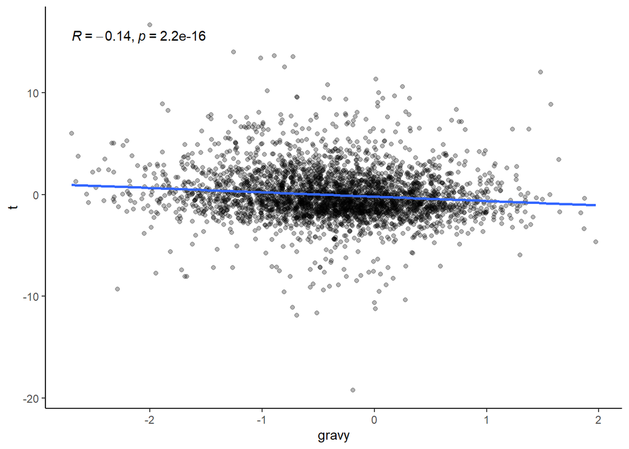

```
##
##  Spearman's rank correlation rho
##
## data:  gravy and t
## S = 7475082512, p-value = 2.239e-16
## alternative hypothesis: true rho is not equal to 0
## sample estimates:
##        rho
## -0.1401116
```

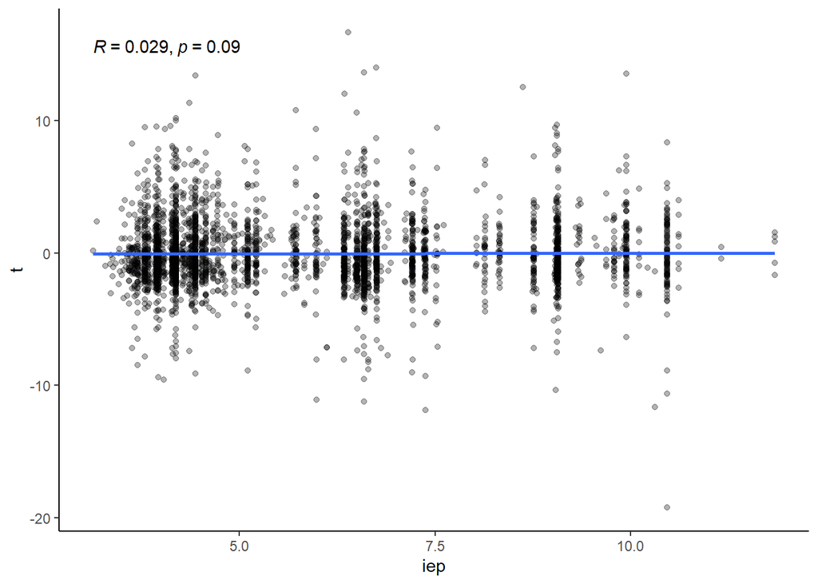

```
##
##  Spearman's rank correlation rho
##
## data:  iep and t
## S = 6.366e+09, p-value = 0.0903
## alternative hypothesis: true rho is not equal to 0
## sample estimates:
##        rho
## 0.02904926
```

Create violin plots for shared/unique features.

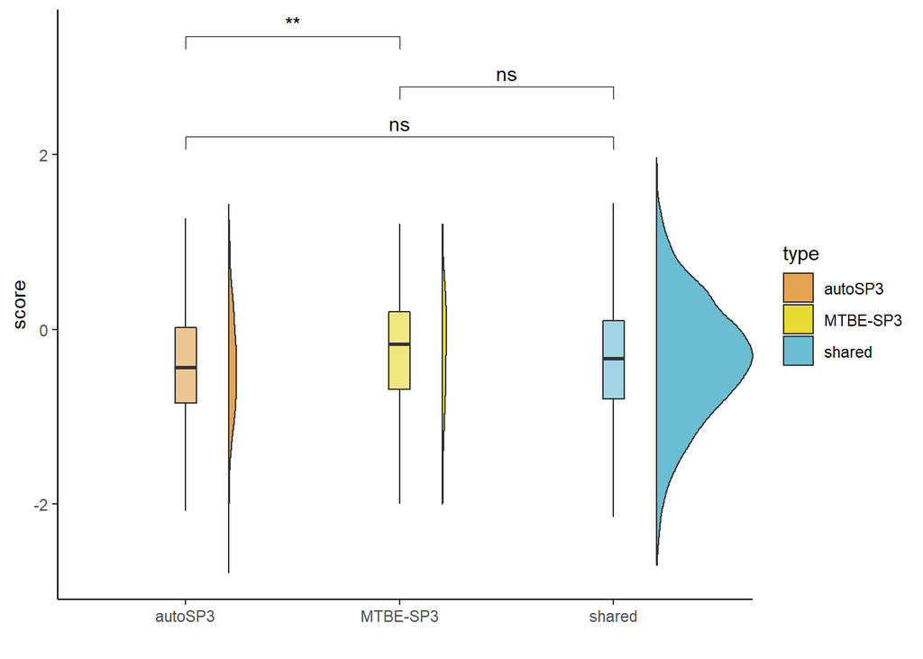

```r
## gravy
feat <- read.table(file = "peptides_unique_features_plasma_Plasma_AFA.txt",
    header = TRUE)
gravy_other <- lapply(feat[, 1], function(aa) calculateGravyScore(aa))
feat <- read.table(file = "peptides_unique_features_plasma_Plasma_TwoPhase.txt",
    header = TRUE)
gravy_tp <- lapply(feat[, 1], function(aa) calculateGravyScore(aa))

## create df
df <- data.frame(rbind(
    cbind(unlist(gravy), "shared"),
    cbind(unlist(gravy_other), "autoSP3"),
    cbind(unlist(gravy_tp), "MTBE-SP3")))
colnames(df) <- c("score", "type")
df$score <- as.numeric(df$score)
df$type <- factor(df$type, levels = c("autoSP3", "MTBE-SP3", "shared"))
comparisons <- list( c("autoSP3", "shared"), c("MTBE-SP3", "shared"),
    c("autoSP3", "MTBE-SP3"))

plot_violin_barplot(df = df, x = "type", y = "score", fill = "type",
    comparisons = comparisons, file = "peptide_violin_gravy_plasma.pdf",
    method = "wilcox.test", paired = FALSE)
```

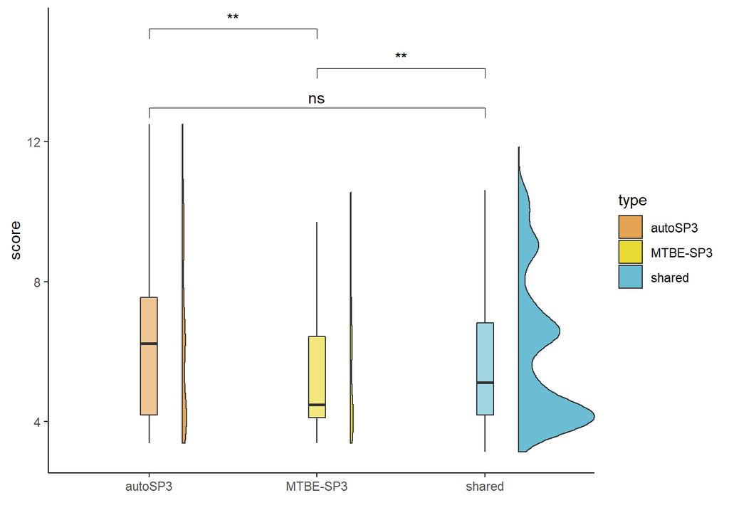

```r
## iep
feat <- read.table(file = "peptides_unique_features_plasma_Plasma_AFA.txt",
    header = TRUE)
iep_other <- lapply(feat[, 1], function(aa) calculateIsoelectricPoint(aa))
feat <- read.table(file = "peptides_unique_features_plasma_Plasma_TwoPhase.txt",
    header = TRUE)
iep_tp <- lapply(feat[, 1], function(aa) calculateIsoelectricPoint(aa))

## create df
df <- data.frame(rbind(
    cbind(unlist(iep), "shared"),
    cbind(unlist(iep_other), "autoSP3"),
    cbind(unlist(iep_tp), "MTBE-SP3")))
colnames(df) <- c("score", "type")
df$score <- as.numeric(df$score)
df$type <- factor(df$type, levels = c("autoSP3", "MTBE-SP3", "shared"))
comparisons <- list( c("autoSP3", "shared"), c("MTBE-SP3", "shared"),
    c("autoSP3", "MTBE-SP3"))

plot_violin_barplot(df = df, x = "type", y = "score", fill = "type",
    comparisons = comparisons, file = "peptide_violin_iep_plasma.pdf",
    method = "wilcox.test", paired = FALSE)
```

# 7 Serum

contrasts:

- Serum_AFA - Serum_TwoPhase_AFA

Upset plot for all condition types.

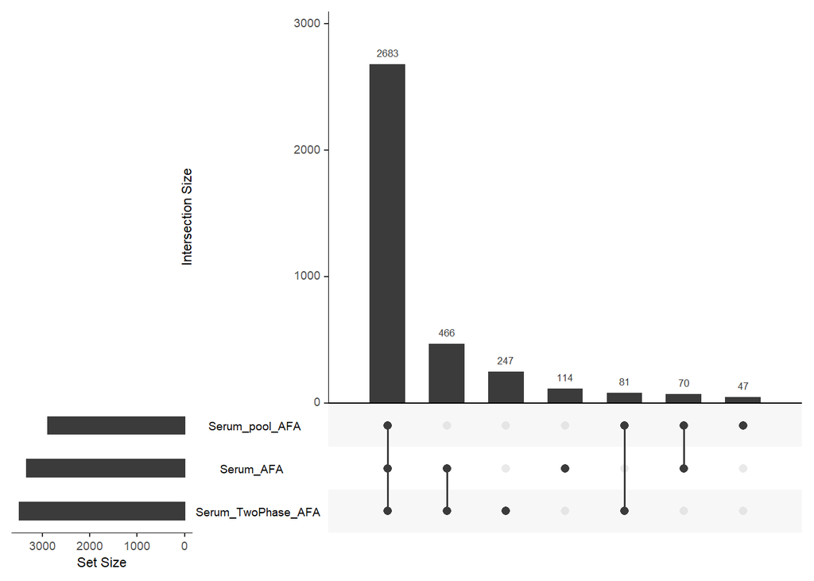

## 7.1 Serum: Overlap, uniqueness of features

The plot shows the interaction of sets between different variables depending on their presence. The dots in the UpSet plot specify if the criteria for presence are fulfilled: Presence is defined by a feature being measured in at least one sample of a set.

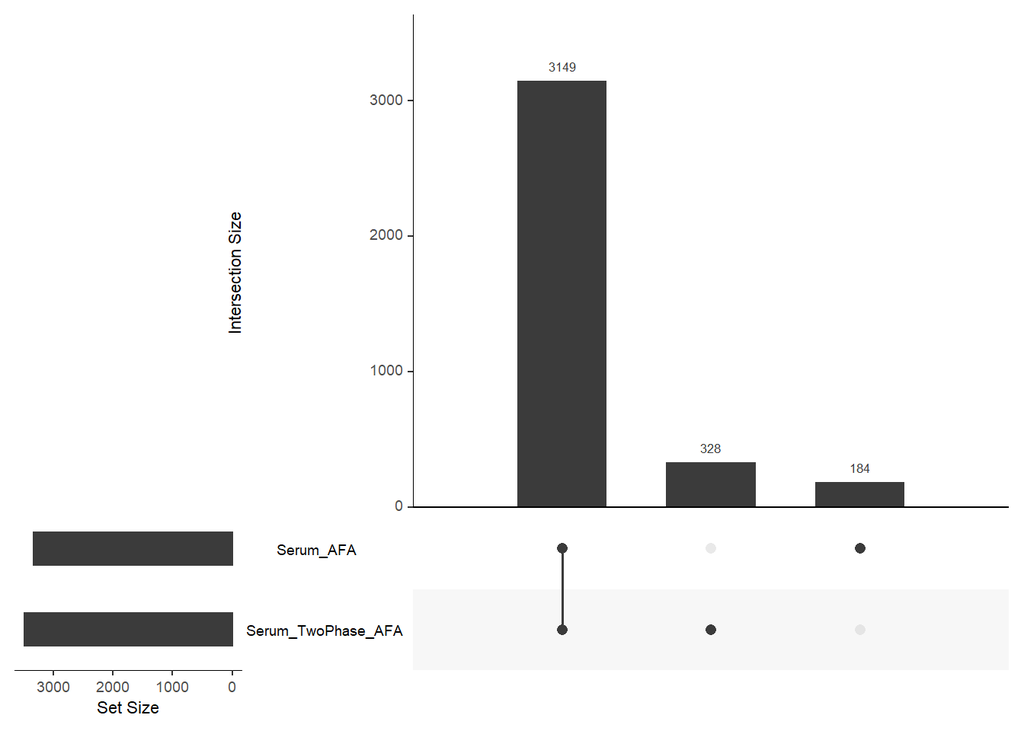

Only continue with the shared features in the following analyses.

## 7.2 Serum: CV

```
## [1] "mean: Serum_AFA"
```

```
## [1] 3.628434
```

```
## [1] "mean: Serum_TwoPhase_AFA"
```

```
## [1] 4.33988
```

```
##
##  Wilcoxon signed rank test with continuity correction
##
## data:  cv_a and cv_b
## V = 1490917, p-value = 8.171e-11
## alternative hypothesis: true location shift is not equal to 0
```

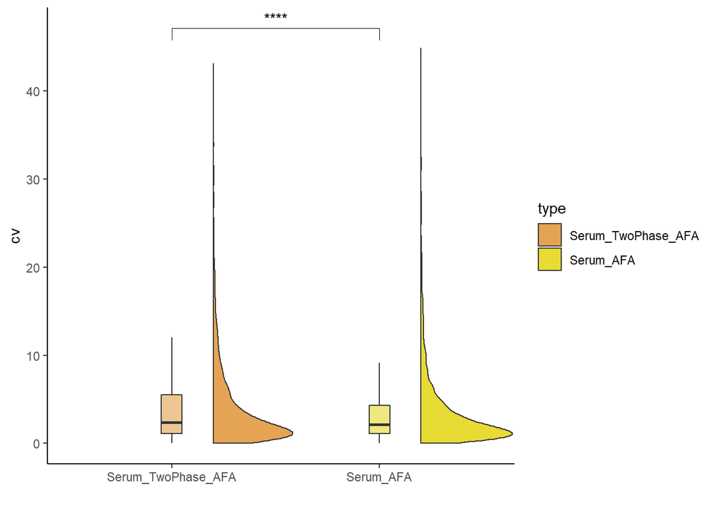

## 7.3 Serum: Differential expression analysis

```
## [1] "## contrast: Serum_AFA - Serum_TwoPhase_AFA"
```

|  | logFC | AveExpr | t | P.Value | adj.P.Val | B |
| --- | --- | --- | --- | --- | --- | --- |
| AAAATGTIFTFR | 0.895200290 | 11.645017 | 0.59722518 | 0.5732965391 | 0.79535245 | -6.3341822 |
| AAAFEEQENETVVVK | -0.006114640 | 6.843090 | -0.01488118 | 0.9891569628 | 0.99420851 | -6.1403502 |
| AADDTWEPFASGK | 1.097639049 | 13.136734 | 2.77543643 | 0.0339774604 | 0.30121356 | -3.7614229 |
| AADIEQQAVFAVFDENK | -0.491368950 | 9.309470 | -1.75071521 | 0.1606679425 | 0.49360327 | -4.8565675 |
| AAFTECCQAADK | -0.368219461 | 12.263683 | -1.96129078 | 0.1000480971 | 0.42905799 | -4.8520305 |
| AAISGENAGLVR | -0.085035499 | 13.861632 | -0.61711631 | 0.5609807169 | 0.78617191 | -6.3211426 |
| AALTELSLGSAYQAMILGVDSK | -0.420313263 | 11.354831 | -2.73885323 | 0.0356119770 | 0.30473401 | -3.8098358 |
| AAMVGMLANFLGFR | 0.843456512 | 11.131132 | 1.24344075 | 0.2624027353 | 0.58644870 | -5.7479429 |
| AAPSVTLFPPSSEELQANK | 0.282115806 | 16.921537 | 1.59765016 | 0.1638234315 | 0.49609731 | -5.3244627 |
| AAQVTIQSSGTFSSK | -0.108933563 | 15.270957 | -0.76562743 | 0.4743951203 | 0.72599619 | -6.2123775 |

[output cut: 490 more lines]

## 7.4 Serum: Association to physico-chemical parameters

Take the t-values and plot against the GRAVY-Score and Isoelectric point (for shared features).

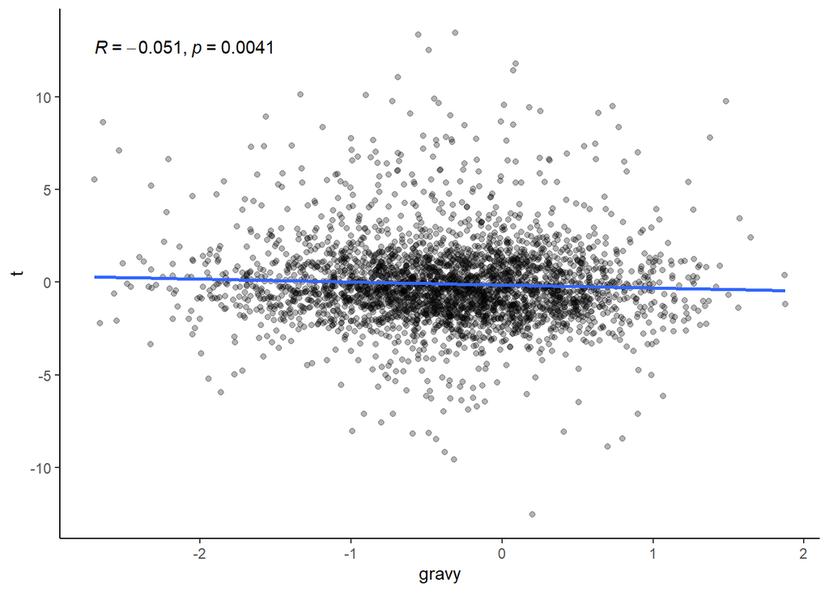

```
##
##  Spearman's rank correlation rho
##
## data:  gravy and t
## S = 5470252737, p-value = 0.004133
## alternative hypothesis: true rho is not equal to 0
## sample estimates:
##         rho
## -0.05109194
```

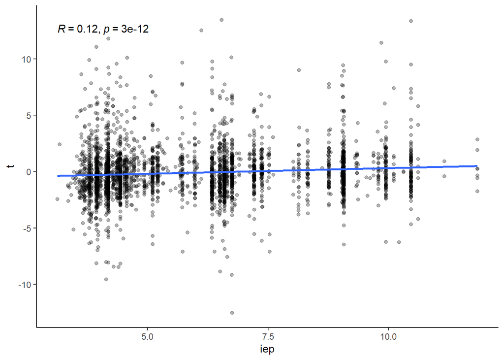

```
##
##  Spearman's rank correlation rho
##
## data:  iep and t
## S = 4559283693, p-value = 2.96e-12
## alternative hypothesis: true rho is not equal to 0
## sample estimates:
##       rho
## 0.1239479
```

Create violin plots for shared/unique features.

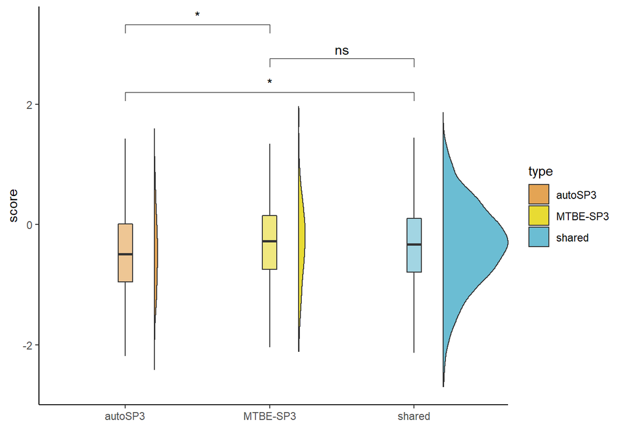

```r
## gravy
feat <- read.table(file = "peptides_unique_features_serum_Serum_AFA.txt",
    header = TRUE)
gravy_other <- lapply(feat[, 1], function(aa) calculateGravyScore(aa))
feat <- read.table(file = "peptides_unique_features_serum_Serum_TwoPhase.txt",
    header = TRUE)
gravy_tp <- lapply(feat[, 1], function(aa) calculateGravyScore(aa))

## create df
df <- data.frame(rbind(
    cbind(unlist(gravy), "shared"),
    cbind(unlist(gravy_other), "autoSP3"),
    cbind(unlist(gravy_tp), "MTBE-SP3")))
colnames(df) <- c("score", "type")
df$score <- as.numeric(df$score)
df$type <- factor(df$type, levels = c("autoSP3", "MTBE-SP3", "shared"))
comparisons <- list( c("autoSP3", "shared"), c("MTBE-SP3", "shared"),
    c("autoSP3", "MTBE-SP3"))

plot_violin_barplot(df = df, x = "type", y = "score", fill = "type",
    comparisons = comparisons, file = "peptide_violin_gravy_serum.pdf",
    method = "wilcox.test", paired = FALSE)
```

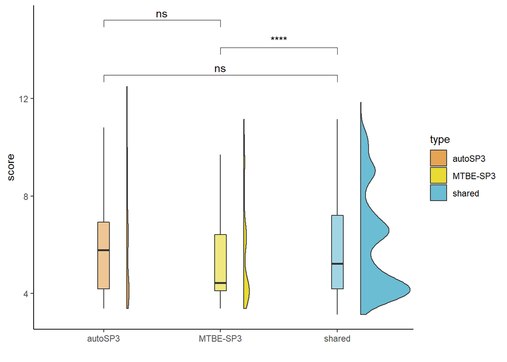

```r
## iep
feat <- read.table(file = "peptides_unique_features_serum_Serum_AFA.txt",
    header = TRUE)
iep_other <- lapply(feat[, 1], function(aa) calculateIsoelectricPoint(aa))
feat <- read.table(file = "peptides_unique_features_serum_Serum_TwoPhase.txt",
    header = TRUE)
iep_tp <- lapply(feat[, 1], function(aa) calculateIsoelectricPoint(aa))

## create df
df <- data.frame(rbind(
    cbind(unlist(iep), "shared"),
    cbind(unlist(iep_other), "autoSP3"),
    cbind(unlist(iep_tp), "MTBE-SP3")))
colnames(df) <- c("score", "type")
df$score <- as.numeric(df$score)
df$type <- factor(df$type, levels = c("autoSP3", "MTBE-SP3", "shared"))
comparisons <- list( c("autoSP3", "shared"), c("MTBE-SP3", "shared"),
    c("autoSP3", "MTBE-SP3"))

plot_violin_barplot(df = df, x = "type", y = "score", fill = "type",
    comparisons = comparisons, file = "peptide_violin_iep_serum.pdf",
    method = "wilcox.test", paired = FALSE)
```

# 8 CV plot for all conditions

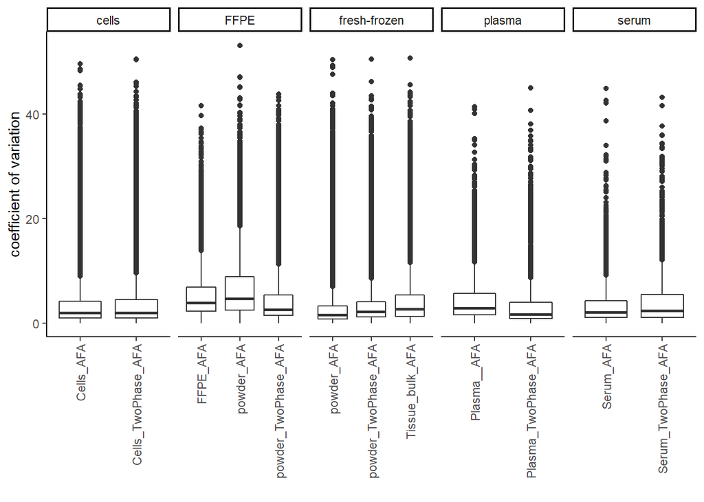

```r
cv_cells_a <- assay(cells)[feat_cells, cells$condition == "Cells_AFA"]
cv_cells_b <- assay(cells)[feat_cells, cells$condition == "Cells_TwoPhase_AFA"]
cv_ff_a <- assay(ff)[feat_ff, ff$condition == "powder_AFA"]
cv_ff_b <- assay(ff)[feat_ff, ff$condition == "powder_TwoPhase_AFA"]
cv_ff_c <- assay(ff)[feat_ff, ff$condition == "Tissue_bulk_AFA"]
cv_ffpe_a <- assay(ffpe)[feat_ffpe, ffpe$condition == "powder_AFA"]
cv_ffpe_b <- assay(ffpe)[feat_ffpe, ffpe$condition == "powder_TwoPhase_AFA"]
cv_ffpe_c <- assay(ffpe)[feat_ffpe, ffpe$condition == "FFPE_AFA"]
cv_plasma_a <- assay(plasma)[feat_plasma, plasma$condition == "Plasma_TwoPhase_AFA"]
cv_plasma_b <- assay(plasma)[feat_plasma, plasma$condition == "Plasma_AFA"]
cv_serum_a <- assay(serum)[feat_serum, serum$condition == "Serum_TwoPhase_AFA"]
cv_serum_b <- assay(serum)[feat_serum, serum$condition == "Serum_AFA"]

## calculate cvs
cv_cells_a <- MatrixQCvis::cv(t(cv_cells_a))[[1]]
cv_cells_b <- MatrixQCvis::cv(t(cv_cells_b))[[1]]
cv_ff_a <- MatrixQCvis::cv(t(cv_ff_a))[[1]]
cv_ff_b <- MatrixQCvis::cv(t(cv_ff_b))[[1]]
cv_ff_c <- MatrixQCvis::cv(t(cv_ff_c))[[1]]
cv_ffpe_a <- MatrixQCvis::cv(t(cv_ffpe_a))[[1]]
cv_ffpe_b <- MatrixQCvis::cv(t(cv_ffpe_b))[[1]]
cv_ffpe_c <- MatrixQCvis::cv(t(cv_ffpe_c))[[1]]
cv_plasma_a <- MatrixQCvis::cv(t(cv_plasma_a))[[1]]
cv_plasma_b <- MatrixQCvis::cv(t(cv_plasma_b))[[1]]
cv_serum_a <- MatrixQCvis::cv(t(cv_serum_a))[[1]]
cv_serum_b <- MatrixQCvis::cv(t(cv_serum_b))[[1]]

## create data frames
cv_cells_a <- data.frame(protein = names(cv_cells_a), cv = cv_cells_a,
    condition = "Cells_AFA", experiment = "cells")
cv_cells_b <- data.frame(protein = names(cv_cells_b), cv = cv_cells_b,
    condition = "Cells_TwoPhase_AFA", experiment = "cells")
cv_ff_a <- data.frame(protein = names(cv_ff_a), cv = cv_ff_a,
    condition = "powder_AFA", experiment = "fresh-frozen")
cv_ff_b <- data.frame(protein = names(cv_ff_b), cv = cv_ff_b,
    condition = "powder_TwoPhase_AFA", experiment = "fresh-frozen")
cv_ff_c <- data.frame(protein = names(cv_ff_c), cv = cv_ff_c,
    condition = "Tissue_bulk_AFA", experiment = "fresh-frozen")
cv_ffpe_a <- data.frame(protein = names(cv_ffpe_a), cv = cv_ffpe_a,
    condition = "powder_AFA", experiment = "FFPE")
cv_ffpe_b <- data.frame(protein = names(cv_ffpe_b), cv = cv_ffpe_b,
    condition = "powder_TwoPhase_AFA", experiment = "FFPE")
cv_ffpe_c <- data.frame(protein = names(cv_ffpe_c), cv = cv_ffpe_c,
    condition = "FFPE_AFA", experiment = "FFPE")
cv_plasma_a <- data.frame(protein = names(cv_plasma_a), cv = cv_plasma_a,
    condition = "Plasma_TwoPhase_AFA", experiment = "plasma")
cv_plasma_b <- data.frame(protein = names(cv_plasma_b), cv = cv_plasma_b,
    condition = "Plasma__AFA", experiment = "plasma")
cv_serum_a <- data.frame(protein = names(cv_serum_a), cv = cv_serum_a,
    condition = "Serum_TwoPhase_AFA", experiment = "serum")
cv_serum_b <- data.frame(protein = names(cv_serum_b), cv = cv_serum_b,
    condition = "Serum_AFA", experiment = "serum")

## rbind data frames
cv_df <- rbind(cv_cells_a, cv_cells_b, cv_ff_a, cv_ff_b, cv_ff_c, cv_ffpe_a,
    cv_ffpe_b, cv_ffpe_c, cv_plasma_a, cv_plasma_b, cv_serum_a, cv_serum_b)
cv_df$condition <- factor(cv_df$condition, levels = sort(unique(cv_df$condition)))

g <- ggplot(cv_df) +
    geom_boxplot(aes(x = condition, y = cv)) +
    facet_wrap(~ experiment, scales = "free_x", nrow = 1) +
    theme_classic() + ylab("coefficient of variation") + xlab("") +
    theme(axis.text.x = element_text(angle = 90,
                                     vjust = 0.5, hjust = 1))
g
```

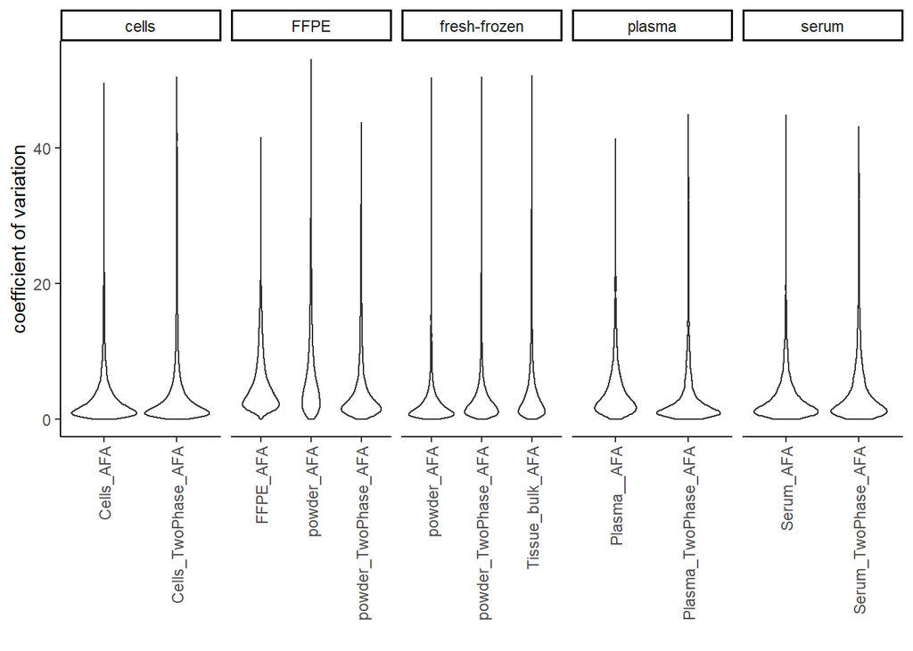

```r
ggsave(g, filename = "coefficient_variation_peptide_boxplot.pdf")
g <- ggplot(cv_df) +
    geom_violin(aes(x = condition, y = cv), scale = "count") +
    facet_wrap(~ experiment, scales = "free_x", nrow = 1) +
    theme_classic() + ylab("coefficient of variation") + xlab("") +
    theme(axis.text.x = element_text(angle = 90,
                                     vjust = 0.5, hjust = 1))
g
```

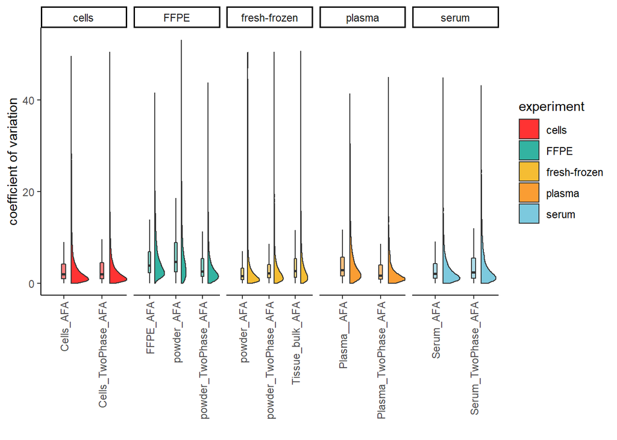

```r
ggsave(g, filename = "coefficient_variation_peptide_violinplot.pdf")
g <- ggplot(data = cv_df, aes_string(x = "condition", y = "cv", fill = "experiment")) +
    geom_flat_violin(position = position_nudge(x = .2, y = 0), alpha = .8,
        scale = "count") +
    theme_classic() +
    guides(color = "none") +
    scale_fill_manual(values = as.character(wes_palette("Darjeeling1",
        type = "discrete"))) +
    geom_boxplot(width = .1, show.legend = FALSE, outlier.shape = NA,
        alpha = 0.5) +
    xlab("") + ylab("coefficient of variation") +
    facet_wrap(~ experiment, scales = "free_x", nrow = 1) +
    theme(axis.text.x = element_text(angle = 90, vjust = 0.5, hjust = 1))
g
```

```r
ggsave(g, filename = "coefficient_variation_peptide_violinboxplot.pdf")
```

# 9 Barplot with overlap (%) for different data sets

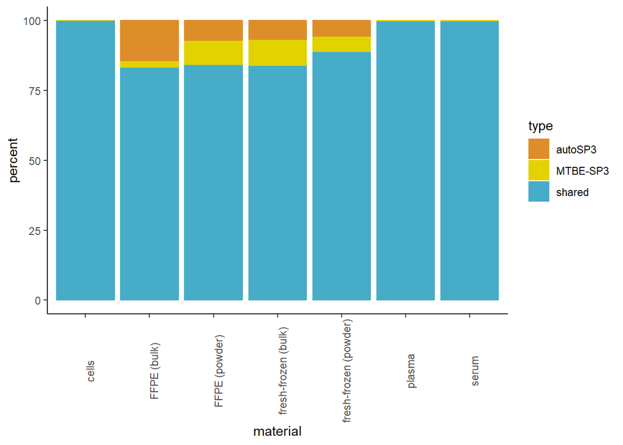

[^1]: European Molecular Biology Laboratory, Meyerhofstrasse 1, 69117 Heidelberg, Germany